# Chapter 3: Introduction to Decision Models

Bob

2025-03-21

```r
# libraries
library('rjags')      # coda.samples
library('jagsUI')     # wrapper for rjags
library('mcmcplots')  # caterplot
library('coda')
library('knitr')
library('dplyr')
library('tidyr')
library('ggplot2')

# functions
coda_sample_2_df <- function(my_coda_sample){
  # Extract data from a coda sample into a dataframe
  seq_along(my_coda_sample) %>% lapply(function(chain){
    df <- my_coda_sample[[chain]] %>% as.matrix %>% as.data.frame
    df['chain'] <- chain
    df
  }) %>%
    bind_rows %>%
    mutate(chain=factor(chain))
}

plot_densities_from_coda_df <- function(vars, coda_df){
  # Make comparative density plots for the given variables
  coda_df %>%
    select(all_of(vars)) %>%
    pivot_longer(cols=vars) %>%
    ggplot(aes(x=value, col=name, fill=name)) + geom_density(alpha=0.6)
}
```

# Deterministic decision tree

This is the model at the end of section 3.4 (p 56).

## Effectiveness data

From [Bibi et al., 1994](https://pubmed.ncbi.nlm.nih.gov/8051377/)

```r
effectiveness_df <- data.frame(
  Description = c("Prophylactic antibiotics", "Placebo"),
  Infection = c(4, 28),
  No_infection = c(129, 108),
  row.names = c("Treatment", "Control")
) %>% mutate(Total = Infection + No_infection)

effectiveness_df %>% kable
```

|  | Description | Infection | No_infection | Total |
| --- | --- | --- | --- | --- |
| Treatment | Prophylactic antibiotics | 4 | 129 | 133 |
| Control | Placebo | 28 | 108 | 136 |

## Resource use and cost data

From Table 3.3, p55. Data is from [Mugford et al., 1989](https://pubmed.ncbi.nlm.nih.gov/2511938/), except for the cost of administering antibiotic which was estimated by Welton et al.

```r
cost_df <- data.frame(
  Parameter = c( "Length of stay, wound infection",
                 "Length of stay, no wound infection",
                 "Cost of inpatient stay per day, wound infection",
                 "Cost of inpatient stay per day, no wound infection",
                 "Cost of prophylactic cephaslosporin, per dose",
                 "Cost of administering the antibiotic, per dose",
                 "Doses administered",
                 "Number of Caesarian sections total",
                 "Number developing wound infections without antibiotics"
              ),
  Estimate = c(8.80, 6.70, 163.03, 107.26, 5.67, 7.00, 3, 486, 41),
  Units=c("days", "days", "£", "£", "£", "£", "count", "count", "count"),
  Variable_name=c("loswd", "losnwd", "cstwd", "cstnwd", "cstPx", "cstadmin", "dose", "nc1", "rc1")
)

cost_df %>% kable
```

| Parameter | Estimate | Units | Variable_name |
| --- | --- | --- | --- |
| Length of stay, wound infection | 8.80 | days | loswd |
| Length of stay, no wound infection | 6.70 | days | losnwd |
| Cost of inpatient stay per day, wound infection | 163.03 | £ | cstwd |
| Cost of inpatient stay per day, no wound infection | 107.26 | £ | cstnwd |
| Cost of prophylactic cephaslosporin, per dose | 5.67 | £ | cstPx |
| Cost of administering the antibiotic, per dose | 7.00 | £ | cstadmin |
| Doses administered | 3.00 | count | dose |
| Number of Caesarian sections total | 486.00 | count | nc1 |
| Number developing wound infections without antibiotics | 41.00 | count | rc1 |

```r
model_code <- "
model {
  cost_nwdpx <- losnwd * cstnwd + dose * (cstPx + cstadmin) # Cost (No infection/Px)
  cost_wdpx <- loswd * cstwd + dose * (cstPx + cstadmin)    # Cost (Infection/Px)
  cost_nwd <- losnwd * cstnwd                               # Cost (No infection/no Px)
  cost_wd <- loswd * cstwd                                  # Cost (Infection/no Px)

  RR <- (a/(a+b))/(c/(c+d))                                 # Relative risk using
                                                            # data from table 3.2

  p1 <- rc1/nc1
  p2 <- RR * p1

  costtrt <- ((1-p2) * cost_nwdpx) + p2 * cost_wdpx         # Total cost (payoff) Px
  costctl <- ((1-p1) * cost_nwd) + p1 * cost_wd             # Total cost (payoff) No Px

}"

cost_data <- with(cost_df, setNames(as.list(Estimate), nm=Variable_name))
effectiveness_data <-  list(
  a=effectiveness_df['Treatment', 'Infection'],
  b=effectiveness_df['Treatment', 'No_infection'],
  c=effectiveness_df['Control', 'Infection'],
  d=effectiveness_df['Control', 'No_infection']
)
deterministic_data <- append(cost_data, effectiveness_data)

# deterministic_data <- list(
#   losnwd=6.7,
#   loswd=8.8,
#   cstnwd=107.26,
#   cstwd=163.03,
#   cstPx=5.67,  # !!! `cstdrug` should be `cstPx`
#   cstadmin=7,
#   dose=3,
#   rc1=41,
#   nc1=486,
#   a=4,
#   b=129,
#   c=28,
#   d=108
# )

results <- jags(
  data = deterministic_data,
  parameters.to.save = c("p1", "p2", "costtrt", "costctl"),
  model.file = model_code %>% textConnection,
  n.chains = 1,
  n.iter=1
)
```

```
##
## Processing function input.......
##
## Done.
##
##
##
## Adaptive phase.....
## Adaptive phase complete
##
## No burn-in specified
##
## Sampling from joint posterior, 1 iterations x 1 chains
##
```

```
##
## Calculating statistics.......
##
## Done.
```

```r
results
```

```
## JAGS output for model '4', generated by jagsUI.
## Estimates based on 1 chains of 1 iterations,
## adaptation = 100 iterations (sufficient),
## burn-in = 0 iterations and thin rate = 1,
## yielding 1 total samples from the joint posterior.
## MCMC ran for 0 minutes at time 2025-04-02 21:58:47.182785.
##
##            mean sd    2.5%     50%   97.5% overlap0 f
## p1        0.084 NA   0.084   0.084   0.084    FALSE 1
## p2        0.012 NA   0.012   0.012   0.012    FALSE 1
## costtrt 765.476 NA 765.476 765.476 765.476    FALSE 1
## costctl 779.047 NA 779.047 779.047 779.047    FALSE 1
##
## overlap0 checks if 0 falls in the parameter's 95% credible interval.
## f is the proportion of the posterior with the same sign as the mean;
## i.e., our confidence that the parameter is positive or negative.
```

The expected costs of the treament and control branches match those in the text on p56.

# Stochastic decision tree

This is the model on pp 59-60.

```r
stochastic_model_code <- "
model{
  lnRR ~ dnorm(theta, prec)                  # Distribution for ln(Relative Risk)
  theta <- log( (a/(a+b)) / (c/(c+d)) )
  prec <- 1/( (1/a) - (1/(a+b)) + (1/c) - (1/(c+d)) )

  p1 ~ dbeta(alpha, beta)                    # Distribution for Prob(Infection/NoPx)
  alpha <- rc1
  beta <- nc1 - rc1

  p2 <- exp(lnRR) * p1                       # Distribution for Prob(Infection/Px)

  loswd ~ dnorm(mnloswd, precwd)             # Distribution for length of stay with infection
  precwd <- 1/pow(sdloswd/sqrt(numwd), 2)

  losnwd ~ dnorm(mnlosnwd, precnwd)          # Distribution for length of stay w/o infection
  precnwd <- 1/pow(sdlosnwd/sqrt(numnwd), 2)

  cstadmin ~ dunif(4, 10)                    # Px administration

  cst.trt <- (1-p2)*((cstPx + cstadmin)*3 + (losnwd*cstnwd)) + p2*((cstPx + cstadmin)*3 + (loswd*cstwd)) # Total cost (payoff) Px

  cst.ctl <- (1-p1)*(losnwd*cstnwd) + p1*(loswd*cstwd) # Total cost (payoff) No Rx

  diff.cost <- cst.trt - cst.ctl             # Difference in cost
}" %>% textConnection()

stochastic_data <- list(
  rc1=41, nc1=486, cstwd=163.03, cstnwd=107.26,
  mnloswd=8.8, sdloswd=3.5,
  mnlosnwd=6.7, sdlosnwd=7.1,
  numwd=41, numnwd=445, # !!! numwd == rc1; numnwd == (nc1 - rc1)
  cstPx=5.67,
  # rt=4, nt=133, rc=28, nc=136,  # !!! Unused variables
  a=4, b=129, c=28, d=108
)

# Here I code the changes from the data for the deterministic model to the
# data for the stochastic one, in case that makes the differences easier to see.

    # Add these:
    # setdiff(names(stochastic_data), names(deterministic_data))
    # "mnloswd"  "sdloswd"  "mnlosnwd" "sdlosnwd"
    # "numwd" ==  rc1;
    # "numnwd" == (nc1 - rc1)
    #
    # Remove or rename these:
    # setdiff(names(deterministic_data), names(stochastic_data))
    #  "loswd" -> "mnloswd"
    #  "losnwd" -> "mnlosnwd"
    #  "cstadmin" hard-coded uniform distribution
    #  "dose": hard-coded !!!

# uncertainty <- c(sdloswd=3.5, sdlosnwd=7.1) # standard deviations from Table 3.4
# rename_me <- c("loswd"="mnloswd", "losnwd"="mnlosnwd")
#
# stochastic_data <- append(deterministic_data, uncertainty)
# for (old_name in names(rename_me)){
#   new_name <- rename_me[[old_name]]
#   names(stochastic_data)[names(stochastic_data) == old_name] <- new_name
# }
# stochastic_data["cstadmin"] <- NULL # now coded as uniform random
# stochastic_data["dose"] <- NULL # the 3 is hard coded now
#
# stochastic_data["numwd"] <- stochastic_data["rc1"];
# stochastic_data["numnwd"] <-  with(stochastic_data, (nc1 - rc1))


parameters_to_save <- c("cst.trt", "cst.ctl", "diff.cost")

stochastic_results <- jags( data = stochastic_data,
                            parameters.to.save = parameters_to_save,
                            model.file = stochastic_model_code,
                            n.chains = 4,
                            n.adapt = 100,
                            n.iter = 50000,
                            n.burnin = 20000)
```

```
##
## Processing function input.......
##
## Done.
##
##
##
## Adaptive phase, 100 iterations x 4 chains
## If no progress bar appears JAGS has decided not to adapt
##
##
##  Burn-in phase, 20000 iterations x 4 chains
##
##
## Sampling from joint posterior, 30000 iterations x 4 chains
##
```

```
##
## Calculating statistics.......
##
## Done.
```

```r
stochastic_results_summary <- summary(stochastic_results) %>% as.data.frame()

stochastic_results_summary
```

```
##               mean       sd      2.5%       25%       50%        75%     97.5%
## cst.trt   766.7260 36.53676 695.04364 742.10765 766.76903 791.263669 838.58238
## cst.ctl   778.9947 35.15381 709.69834 755.33080 779.01799 802.726818 847.86297
## diff.cost -12.2687 12.77026 -38.76887 -20.49063 -11.69169  -3.504098  11.16412
##                Rhat  n.eff overlap0         f
## cst.trt   0.9999897 120000        0 1.0000000
## cst.ctl   1.0000030 120000        0 1.0000000
## diff.cost 1.0000209  69217        1 0.8348833
```

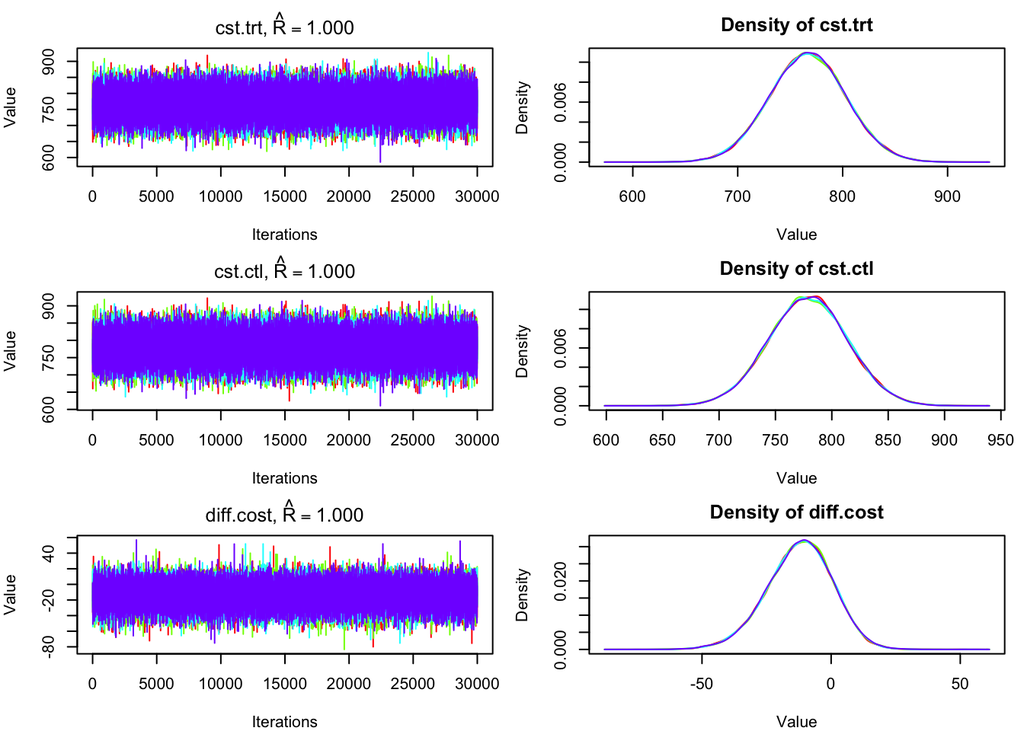

```r
plot(stochastic_results)
```

### Prior distributions

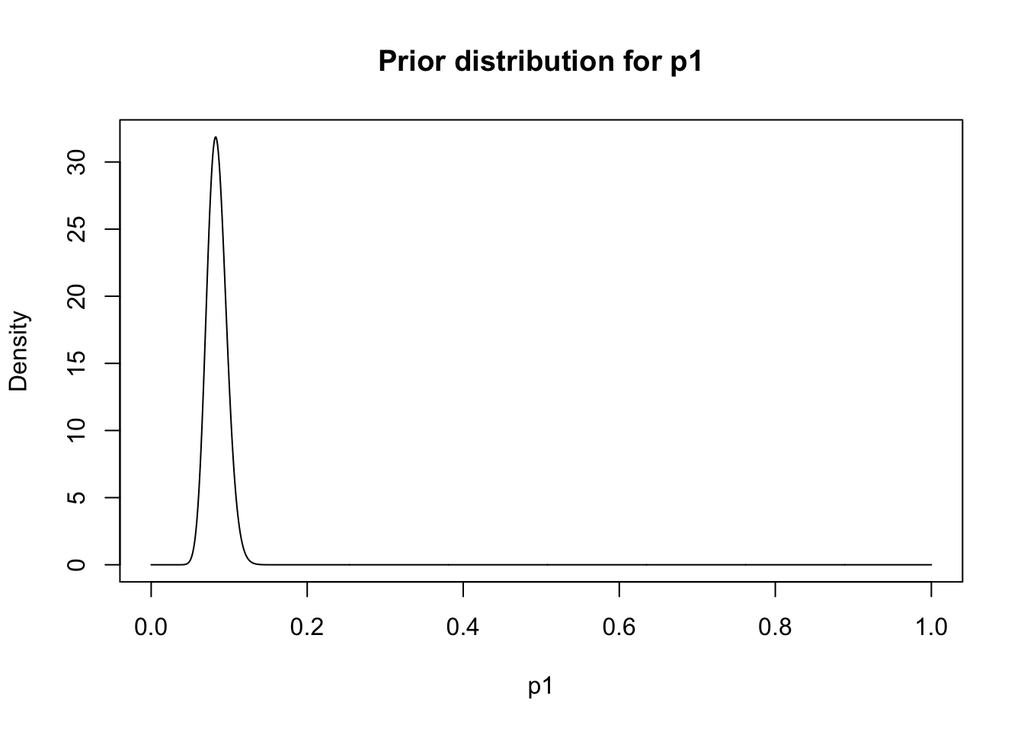

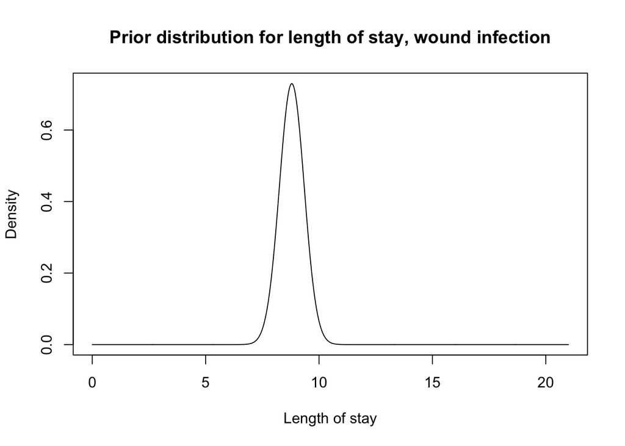

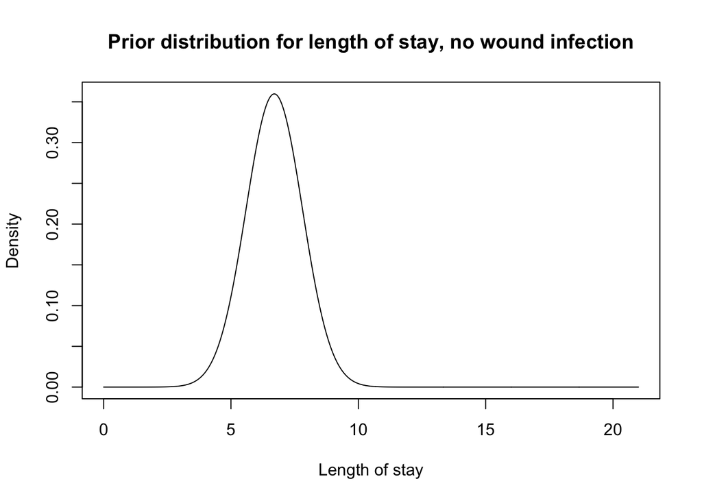

```r
with(stochastic_data, {
  curve(dbeta(x, rc1, nc1 - rc1),
        from = 0, to = 1,
        n=1001,
        xlab = "p1",
        ylab = "Density",
        main = "Prior distribution for p1");

  curve(dnorm(x, mean=mnloswd, sd=sdloswd/sqrt(numwd)),
        from=0, to=21,
        n=1001,
        xlab = "Length of stay",
        ylab = "Density",
        main = "Prior distribution for length of stay, wound infection");

  curve(dnorm(x, mean=mnlosnwd, sd=sdlosnwd/sqrt(numwd)),
        from=0, to=21,
        n=1001,
        xlab = "Length of stay",
        ylab = "Density",
        main = "Prior distribution for length of stay, no wound infection");
})
```

### Simulation results

Here we re-sample an exissting model and plot densities of several variables using the R functions defined at the beginning of this document.

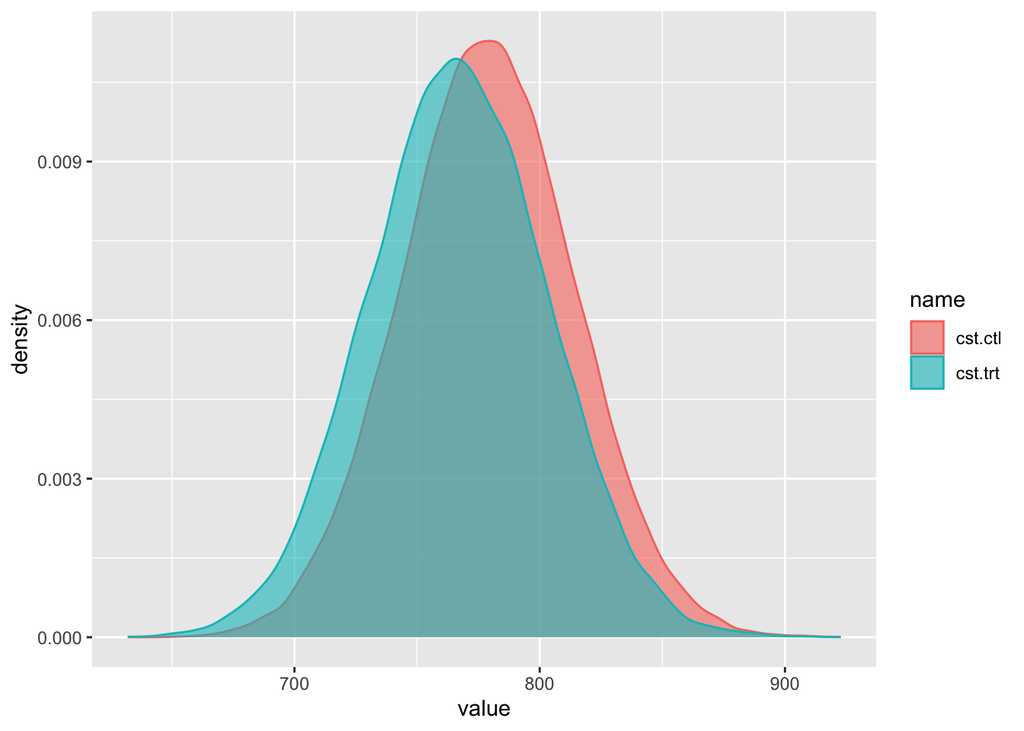

```r
my_vars <- c('p1', 'p2', 'cst.trt', 'cst.ctl', 'diff.cost')
coda_df <- coda.samples(stochastic_results$model, variable.names = my_vars,
    n.iter = 10000) %>%
  coda_sample_2_df %>%
  sample_frac(1L) # randomly scramble chain order

plot_densities_from_coda_df(c('cst.trt', 'cst.ctl'), coda_df)
```

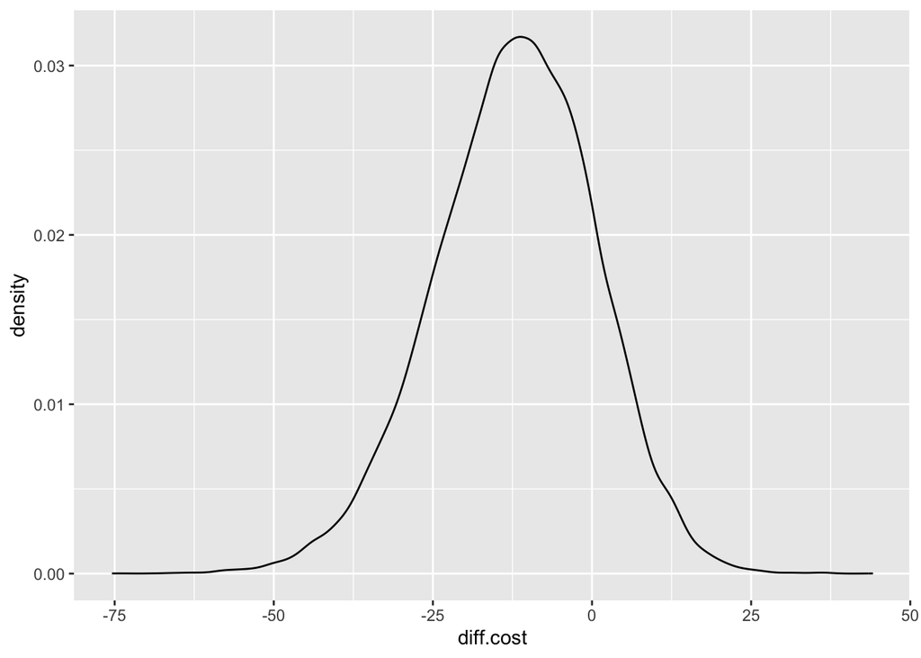

```r
coda_df %>% ggplot(aes(x=diff.cost)) + geom_density()
```

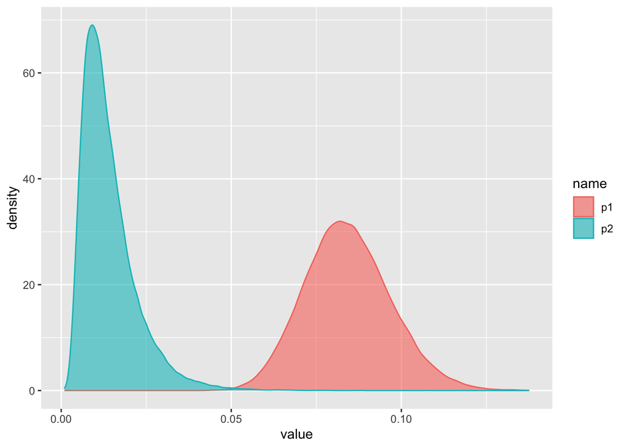

```r
plot_densities_from_coda_df(c('p1', 'p2'), coda_df)
```

## Economic evaluation

Here we add the code from p65 to the model above.

```r
economic_model_code <- "
model{
  lnRR ~ dnorm(theta, prec)                  # Distribution for ln(Relative Risk)
  theta <- log( (a/(a+b)) / (c/(c+d)) )
  prec <- 1/( (1/a) - (1/(a+b)) + (1/c) - (1/(c+d)) )

  p1 ~ dbeta(alpha, beta)                    # Distribution for Prob(Infection/NoPx)
  alpha <- rc1
  beta <- nc1 - rc1

  p2 <- exp(lnRR) * p1                       # Distribution for Prob(Infection/Px)

  loswd ~ dnorm(mnloswd, precwd)             # Distribution for length of stay with infection
  precwd <- 1/pow(sdloswd/sqrt(numwd), 2)

  losnwd ~ dnorm(mnlosnwd, precnwd)          # Distribution for length of stay w/o infection
  precnwd <- 1/pow(sdlosnwd/sqrt(numnwd), 2)

  cstadmin ~ dunif(4, 10)                    # Px administration

  cst.trt <- (1-p2)*((cstPx + cstadmin)*3 + (losnwd*cstnwd)) + p2*((cstPx + cstadmin)*3 + (loswd*cstwd)) # Total cost (payoff) Px

  cst.ctl <- (1-p1)*(losnwd*cstnwd) + p1*(loswd*cstwd) # Total cost (payoff) No Rx

  diff.cost <- cst.trt - cst.ctl             # Difference in cost


  # Economic evaluation code from pp 65-66

  totQALYs.wd <- ((QALYwd/365)*loswd) + ((Fullhealth/365)*(fllwupdays-loswd))     # QALYs (infection)
  totQALYs.nwd <- ((QALYnwd/365)*losnwd) + ((Fullhealth/365)*(fllwupdays-losnwd)) # QALYs (No infection)

  QALYs.trt <- (1-p2) * totQALYs.nwd + p2 * totQALYs.wd  # QALYs (Px)
  QALYs.ctl <- (1-p1) * totQALYs.nwd + p1 * totQALYs.wd  # QALYs (no px)
  diff.QALYs <- (QALYs.trt - QALYs.ctl)                  # Difference in QALYs

  for (k in 1:M)
  {
    lambda[k] <- (k-1) * 2000
    INB[k] <- lambda[k] * diff.QALYs - diff.cost  # !!! not `delta.Qalys` or `delta.cost`
    ProbCE[k] <- step(INB[k])
  }
}
" %>% textConnection()

# economic_data <- list(
#   rc1=41, nc1=486, cstwd=163.03, cstnwd=107.26,
#   mnloswd=8.8, sdloswd=3.5,
#   mnlosnwd=6.7, sdlosnwd=7.1,
#   numwd=41, numnwd=445,
#   cstPx=5.67,
#   a=4, b=129, c=28, d=108,
#   # additional data for economic evaluation
#   M=21, QALYwd=0.68, QALYnwd=0.88, Fullhealth=1, fllwupdays=20
# )

economic_data <- append(stochastic_data,
  # additional data for economic evaluation
  list(M=21, QALYwd=0.68, QALYnwd=0.88, Fullhealth=1, fllwupdays=20)
)

parameters_to_save <- c(#"ProbCE",
  "cst.trt", "cst.ctl", "diff.QALYs", "diff.cost", "p1", "p2")


economic_results <- jags(data = economic_data,
            parameters.to.save = parameters_to_save,
            model.file = economic_model_code,
            n.chains = 1,
            n.adapt = 100,
            n.iter = 50000,
            n.burnin = 20000)
```

```
##
## Processing function input.......
##
## Done.
##
##
##
## Adaptive phase, 100 iterations x 1 chains
## If no progress bar appears JAGS has decided not to adapt
##
##
##  Burn-in phase, 20000 iterations x 1 chains
##
##
## Sampling from joint posterior, 30000 iterations x 1 chains
##
```

```
##
## Calculating statistics.......
##
## Done.
```

```r
economic_results_summary <- summary(economic_results) %>% as.data.frame()

economic_results_summary
```

```
##                     mean           sd          2.5%           25%           50%
## cst.trt     7.667789e+02 3.600837e+01  6.956859e+02  7.425756e+02  7.668439e+02
## cst.ctl     7.791666e+02 3.474350e+01  7.108233e+02  7.560289e+02  7.791925e+02
## diff.QALYs  3.877706e-04 8.065931e-05  2.379495e-04  3.336402e-04  3.845927e-04
## diff.cost  -1.238770e+01 1.275628e+01 -3.894611e+01 -2.055244e+01 -1.197229e+01
## p1          8.433446e-02 1.257657e-02  6.142240e-02  7.552249e-02  8.373402e-02
## p2          1.404349e-02 8.242687e-03  4.178683e-03  8.427570e-03  1.213284e-02
##                      75%        97.5% Rhat n.eff overlap0         f
## cst.trt     7.908521e+02 8.372737e+02   NA     1        0 1.0000000
## cst.ctl     8.026302e+02 8.467858e+02   NA     1        0 1.0000000
## diff.QALYs  4.387703e-04 5.569101e-04   NA     1        0 0.9999333
## diff.cost  -3.567415e+00 1.126679e+01   NA     1        1 0.8346333
## p1          9.244758e-02 1.105356e-01   NA     1        0 1.0000000
## p2          1.751399e-02 3.540972e-02   NA     1        0 1.0000000
```

## Stochastic economic decision model results

### Cost-Effectiveness

Figure 3.4: Cost-effectiveness plane (10000 simulations) for Caesarean section example.

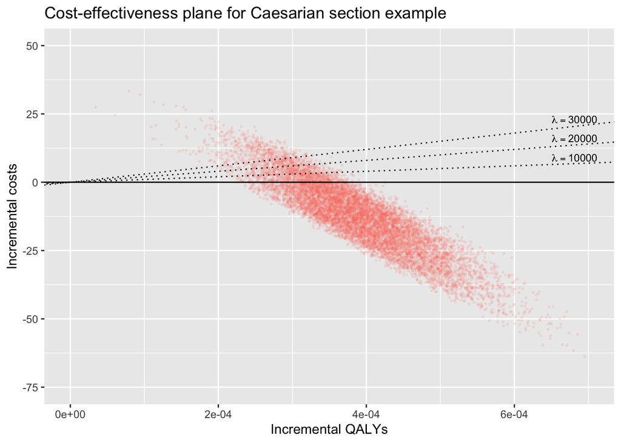

```r
ce_vars <- c("diff.QALYs", "diff.cost")
ce_df <- coda.samples(economic_results$model, variable.names = ce_vars,
    n.iter = 10000) %>% coda_sample_2_df

XLIM = c(0, 7e-4)     # use same limits as chapter 3
YLIM = c(-75, 50)
LAMBDAS = 10000*(1:3)
ce_df %>%
  ggplot(aes(x=diff.QALYs, y=diff.cost, col=chain)) +
  geom_point(size=0.5, alpha=0.1) +
  geom_abline(slope=0, intercept=0, linetype='solid') +
  geom_abline(slope=LAMBDAS, intercept=0, linetype='dotted') +
  theme(legend.position="none") +
  labs(x = "Incremental QALYs", y = "Incremental costs", title="Cost-effectiveness plane for Caesarian section example") +
  coord_cartesian(xlim=XLIM, ylim=YLIM) +
  annotate("text", x = XLIM[2], y = LAMBDAS * XLIM[2],
           size=3, hjust=0.8, vjust=-0.25,
           label = paste("lambda ==", LAMBDAS), parse=TRUE)
```

```r
# save plot to compare to Ch. 7
ggsave("ce_scatterplot_ch3.png")
```

### Cost-effectiveness

```r
inb_vars <- c("INB", "ProbCE")
inb_df <- coda.samples(economic_results$model, variable.names = inb_vars,
    n.iter = 10000) %>%
  coda_sample_2_df %>%
  group_by(chain) %>%
  mutate(iteration=row_number()) %>%
  ungroup() %>%
  as.data.frame

inb_df_long <- inb_df %>%
  pivot_longer(
    cols=1:42,
    names_to=c("metric", "k"),
    names_pattern="(INB|ProbCE)\\[(\\d+)\\]",
    values_to="value"
  ) %>%
  mutate(k=as.integer(k), lambda=2000*(k-1))
```

### Cost-effectiveness acceptability curve for Caesarian section example.

Figure 3.5 [also 3.6(c)]. WTP = “Willingness To Pay”

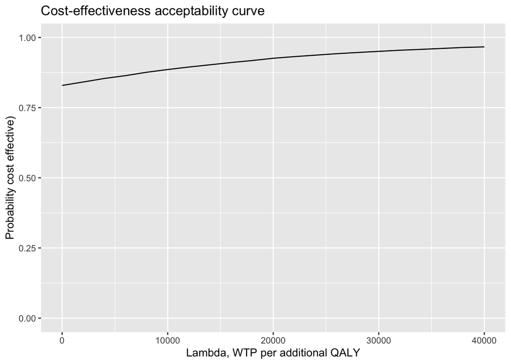

```r
inb_df_long %>%
  group_by(metric, lambda) %>%
  filter(metric=="ProbCE") %>%
  summarize(P_CE=mean(value)) %>%
  ggplot(aes(x=lambda, y=P_CE, group=metric)) + geom_line() +
    ylim(0,1) +
    ylab("Probability cost effective)") +
    xlab("Lambda, WTP per additional QALY") +
    ggtitle("Cost-effectiveness acceptability curve")
```

### Expected net benefit (INB) and 95% interval for a range of lambda values.

Figure 3.6(b): Expected incremental net benefit and 95% interval for a range of lambda.

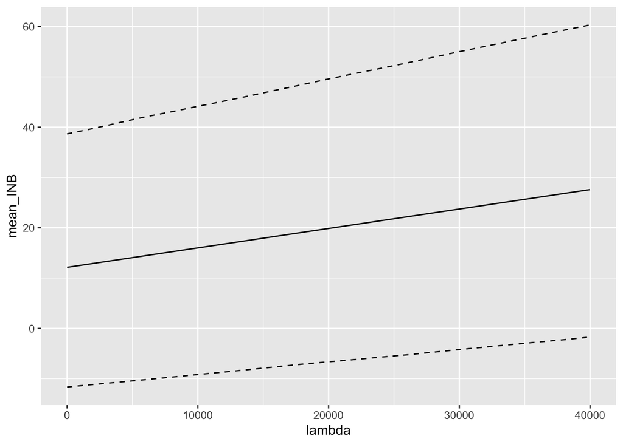

```r
 # quantile(probs = c(2.5, 50, 97.5)/100)
inb_df_long %>%
  group_by(metric, lambda) %>%
  filter(metric=="INB") %>%
  summarize(
    mean_INB=mean(value),
    lo_end=quantile(value, probs=0.025),
    hi_end=quantile(value, probs=0.975)) %>%
  ggplot(aes(x=lambda, group=metric)) +
    geom_line(aes(y=mean_INB)) +
    geom_line(aes(y=lo_end), linetype="dashed") +
    geom_line(aes(y=hi_end), linetype="dashed")
```

# Code for Exercises

## `Model_1_decision_model_odc.txt`

This is the code for Exercise 3.1, a deterministic decision tree comparing the use of prophylactic neuaminidase inhibitors (NIs) to standard care for influenza.

```r
model_code <- "model
{

  # DECISION MODEL
  costtrt <- ((1-p2) *(cdoc+cdrug) +p2* (cdoc+(cdrug)+cflu))
  costctl <- ((1-p1)*(cdoc)+p1*(cdoc+cflu))
  diff.cost <- costtrt-costctl

}" %>% textConnection

#DATA

data <- list(
  cdrug=118,    # cost of neuraminidase treatment
  cdoc=19,      # cost of visit to GP
  cflu=100,     # cost of treating flu
  p1=0.05,      # probability of contracting flu under standard care
  p2=0.03       # probability of contracting flu under NI prophylaxis
)

#RESULTS

results <- jags(
  data = data,
  # inits = NA,
  parameters.to.save = c("cdrug", "cdoc", "cflu", "p1", "p2",
                         "costtrt", "costctl", "diff.cost"),
  model.file = model_code,
  n.chains = 1,
  n.iter=1
)
```

```
##
## Processing function input.......
##
## Done.
##
##
##
## Adaptive phase.....
## Adaptive phase complete
##
## No burn-in specified
##
## Sampling from joint posterior, 1 iterations x 1 chains
##
```

```
##
## Calculating statistics.......
##
## Done.
```

```r
results
```

```
## JAGS output for model '7', generated by jagsUI.
## Estimates based on 1 chains of 1 iterations,
## adaptation = 100 iterations (sufficient),
## burn-in = 0 iterations and thin rate = 1,
## yielding 1 total samples from the joint posterior.
## MCMC ran for 0 minutes at time 2025-04-02 21:58:59.311094.
##
##             mean sd   2.5%    50%  97.5% overlap0 f
## cdrug     118.00 NA 118.00 118.00 118.00    FALSE 1
## cdoc       19.00 NA  19.00  19.00  19.00    FALSE 1
## cflu      100.00 NA 100.00 100.00 100.00    FALSE 1
## p1          0.05 NA   0.05   0.05   0.05    FALSE 1
## p2          0.03 NA   0.03   0.03   0.03    FALSE 1
## costtrt   140.00 NA 140.00 140.00 140.00    FALSE 1
## costctl    24.00 NA  24.00  24.00  24.00    FALSE 1
## diff.cost 116.00 NA 116.00 116.00 116.00    FALSE 1
##
## overlap0 checks if 0 falls in the parameter's 95% credible interval.
## f is the proportion of the posterior with the same sign as the mean;
## i.e., our confidence that the parameter is positive or negative.
```

# Errata

Text that should be deleted is marked in [square brackets]; text that should be added is marked in {curly braces}.

- p 47:
  - Equation 3.2 is about Odds Ratio, not Relative Risk. It should be $ var(ln(OR)) = 1/a + 1/b + 1/c + 1/d $
- p 54:
  - “estimate [the ]the payoffs”
- p 59:
  - An additional set of parentheses is needed to make the whole expression an argument of the log function: `theta <- log( (a/(a+b))/(c/(c+d)) )`
- p 60:
  - `dose` is hard-coded as `3`, where in the deterministic version it was specified as a data variable. It would be more consistent to do it the same way in both programs.
- p 61:
  - “However, in the situation where the new treatment is either more effective [but less]{and more} costly …”
- p 63:
  - Figure 3.6(a) basically repeats Figure 3.4.
  - Figure 3.6(c) basically repeats Figure 3.5.
- p 69:
  - “… relevancy of evidence should be defined more broadly than afforded in Table 3.[1]{7}.”